# Preprocessed

## Purely Data Driven Blog

2017-10-07

##### Import libraries

```python
import pandas as pd # data analysis
import matplotlib.pyplot as plt # default plotting library (line below: make plotting in Jupyter possible)
import seaborn as sns # user friendly visualisations
%matplotlib inline
import warnings # disable matplotlib warnings (you may not need that)
warnings.filterwarnings("ignore", module="matplotlib")
```

##### Set options for Pandas and Seaborn

This is not required, but it's a nice to have

```python
pd.set_option('display.max_columns', 100)
pd.set_option('display.max_rows', 100)
pd.set_option('max_colwidth', 800)
sns.set(style='ticks', context='poster')
sns.set_style("whitegrid")
```

##### First look at Apple Health files

Unzip the export.zip file into your files with the Notebook, let's list the contents for the folder

```python
!ls
```

```
My Apple Health Data Analysis.ipynb  trips-df.csv
Trip Data Analysis.ipynb	     trips_from_Nov2014.txt
export.xml			     weekly_apple_health_data.csv
export_cda.xml
```

Actually - there is nothing interesting in the **export_cda.xml** file, so let's take a look at the **export.xml** file. If the pay attention to the content, we'll notice that the main elements in the xml are the Records, so let's take a look at a sample record now:

```python
with open('export.xml') as f:
    healthData = f.read()
    print(healthData.split("Record")[100:102])
```

```
[' type="HKQuantityTypeIdentifierStepCount" sourceName="iPhone" unit="count" creationDate="2014-12-01 22:28:12 +0100" startDate="2014-12-01 20:41:17 +0100" endDate="2014-12-01 20:41:20 +0100" value="4"/>\n <', ' type="HKQuantityTypeIdentifierStepCount" sourceName="iPhone" unit="count" creationDate="…
```

##### Parsing the file

Based on the sample records above (and a few more manually inspected records) - we can start to determine a structure here. Let's write some Python code to extract the attributes for the analysis

```python
import xml.etree.ElementTree as ET # import xml parsing library
e = ET.parse('export.xml').getroot() # parse xml file
```

```python
len([rec for rec in e.findall('Record')]) # count Record elements
```

```
162245
```

Let's define a function to parse a specific type of elements and extract the most interesting attributes for a activity type

```python
def extractHealthData(elType, activityType):
    records = []
    for rec in e.findall(elType):
        if rec.get('type') and rec.get('type') == activityType:
            records.append({'unit': rec.get('unit'), 'endDate': rec.get('endDate'), 'value': rec.get('value')})
    return records
```

```python
records = extractHealthData('Record', 'HKQuantityTypeIdentifierDistanceWalkingRunning')
```

##### Pandas Dataframe

Finally we can turn our array into the Pandas dataframe!

```python
df = pd.DataFrame(records)
df.head(2) # display first 2 rows
```

|  | endDate | unit | value |
| --- | --- | --- | --- |
| 0 | 2014-12-01 16:49:11 +0100 | km | 0.01106 |
| 1 | 2014-12-01 16:49:21 +0100 | km | 0.01343 |

##### Data types

Date-time and value properties are actually strings, so let's convert them to proper data types

```python
df['endDate'] = pd.to_datetime(df['endDate'])
df['value'] = df['value'].astype(float)
```

```python
df.dtypes # confirmed!!
```

```
endDate    datetime64[ns]
unit               object
value             float64
dtype: object
```

Take a first look at the value attribute

```python
df.describe() # min, max, mean
```

|  | value |
| --- | --- |
| count | 79243.000000 |
| mean | 0.060221 |
| std | 0.157299 |
| min | 0.000095 |
| 25% | 0.005930 |
| 50% | 0.009757 |
| 75% | 0.043929 |
| max | 2.006620 |

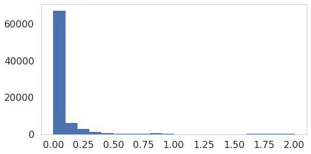

```python
df['value'].hist(bins=20, grid=False, figsize=(8,4)); # distribution
```

##### Time Series Analysis

First - let's set the index to the date column

```python
df.set_index('endDate', inplace=True)
df.head()
```

| endDate | unit | value |
| --- | --- | --- |
| 2014-12-01 15:49:11 | km | 0.01106 |
| 2014-12-01 15:49:21 | km | 0.01343 |
| 2014-12-01 15:49:31 | km | 0.01539 |
| 2014-12-01 15:49:41 | km | 0.01394 |
| 2014-12-01 15:49:51 | km | 0.01314 |

As we can see - data (in km) is being sampled every 10 seconds. For our excercise - daily sampling will do just fine, let's use Pandas **resample** method to do that

```python
dailyKm = df['value'].resample('D').sum()
pd.DataFrame(dailyKm).to_csv('daily_apple_health_data.csv')
dailyKm.head()
```

```
endDate
2014-12-01     1.182150
2014-12-02     4.139710
2014-12-03     3.096390
2014-12-04    10.237749
2014-12-05     3.174237
Freq: D, Name: value, dtype: float64
```

##### Plot an interactive visualisation for weekly patterns

```python
import plotly.plotly as py
import cufflinks as cf
cf.set_config_file(offline=True, world_readable=True)
weeklyKm = df['value'].resample('W').sum()
weeklyKm.iplot(fill=True);
```

[interactive chart not shown]

Just out of curiosity - let's resample the data at the yearly level and compare the years, hopefully it's going up ;-)

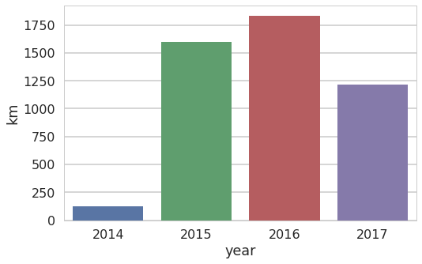

```python
yearlyKm = pd.DataFrame(df['value'].resample('A').sum())
plt.figure(figsize=(8,5))
yearlyKm['year'] = yearlyKm.index.map(lambda x: x.year)
ax = sns.barplot(x="year", y="value", data=yearlyKm.reset_index())
ax.set_ylabel('km');
```